# HS2_IS457_33

# Do not remove any of the comments. These are marked by

# HW 2 - Due Monday, Sep 24 2018 in moodle and for non-online students hardcopy in class.

# (1). Please upload R code and report to Moodle with filename: HW2_IS457_YourCourseID.

# (2). Turn in hard copy of your report in class.

### Class ID: 33

# In this assignment you will practice manipulating vectors and dataframes.

# You will take subsets, create new data structures, and end with creating a fantastic plot.

# You will work with the CO2 dataset in the R library and a dataset called SFHousing.

# Before beginning with the datasets however, you will do some warm up exercises.

# PART 1. Warm up (4 pts)

# Q1. Create a Vector like this (0 0 0 3 3 3 6 6 6 9 9 9 12 12 12 15 15 15 18 18 18)

# with functions seq() and rep() and call it “vec” (1 pt)

### Your code below

```r
vec=rep(seq(0, 18, by = 3), each = 3)
```

# Q2. Calculate the fraction of elements in vec that are more than or equal to 9. (2 pts)

# hint: R can do vectorized operations.

### Your code below

```r
length(which(vec>=9))/length(which(vec>=0))
```

```
## [1] 0.5714286
```

# Q3. Create a Vector like this (1 2 2 3 3 3 4 4 4 4 5 5 5 5 5)

# with functions rep() and the : operator (1 pt)

### Your code below

```r
rep(1:5, 1:5)
```

```
##  [1] 1 2 2 3 3 3 4 4 4 4 5 5 5 5 5
```

# PART II. CO2 Data (9 pts)

# Q4. Use R to generate descriptions of the CO2 data which is already available with the base R installation (it

# is called CO2 in R. Please note that we are using the CO2 dataset and not the similarly named co2 dataset).

# Print out the summary of each column and the dimensions of the dataset. (2 pts.)

# (hint: you may find the summary() and dim() useful).

# Write up your descriptive findings and observations of the R output. (1 pt.)

### Your code below:

```r
dim(CO2)
```

```
## [1] 84  5
```

```r
summary(CO2)
```

```
##      Plant             Type         Treatment       conc
##  Qn1    : 7   Quebec     :42   nonchilled:42   Min.   :  95
##  Qn2    : 7   Mississippi:42   chilled   :42   1st Qu.: 175
##  Qn3    : 7                                    Median : 350
##  Qc1    : 7                                    Mean   : 435
##  Qc3    : 7                                    3rd Qu.: 675
##  Qc2    : 7                                    Max.   :1000
##  (Other):42
##      uptake
##  Min.   : 7.70
##  1st Qu.:17.90
##  Median :28.30
##  Mean   :27.21
##  3rd Qu.:37.12
##  Max.   :45.50
##
```

```r
help("CO2")
```

### Your answer below:

```r
# The CO2 datatset contains 84 ovservations of 5 variables. There are three factor variables (plant, type, Treatment)
# and two numeric variables (conc and uptake). The variable Plant creates a unique identifier for each plant, type
# gives us the origin of the plant, treatment tells us whether it was chilled or non chilled, conc gives us the ambient
# carbon dioxide concentrations, and uptake gives us the CO2 uptake rates. R gives us a summary of 42 plants from each
# region, and 42 treated both chilled and nonchilled. It also gives us min, max, median, mean, and 1st and 3rd
# quartile values of the numeric variables.
```

# Q5. Show last 8 plants’ uptake values (1 pt.)

### Your code below:

```r
CO2$uptake[77:84]
```

```
## [1] 14.4 10.6 18.0 17.9 17.9 17.9 18.9 19.9
```

# Q6. Show all plants’ uptake values except the first 20 plants’. (1 pt.)

### Your code below:

```r
CO2$uptake[-1:-20]
```

```
##  [1] 45.5 14.2 24.1 30.3 34.6 32.5 35.4 38.7  9.3 27.3 35.0 38.8 38.6 37.5
## [15] 42.4 15.1 21.0 38.1 34.0 38.9 39.6 41.4 10.6 19.2 26.2 30.0 30.9 32.4
## [29] 35.5 12.0 22.0 30.6 31.8 32.4 31.1 31.5 11.3 19.4 25.8 27.9 28.5 28.1
## [43] 27.8 10.5 14.9 18.1 18.9 19.5 22.2 21.9  7.7 11.4 12.3 13.0 12.5 13.7
## [57] 14.4 10.6 18.0 17.9 17.9 17.9 18.9 19.9
```

# Q7. Calculate the mean of uptake subseted by the “Treatment” variable.(1 pt)

# hint: apply function family.

### Your code below:

```r
tapply(CO2$uptake, CO2$Treatment, mean, na.rm=TRUE)
```

```
## nonchilled    chilled
##   30.64286   23.78333
```

# Q8. Create a logical vector uptake_treatment . (2 pts)

# For the plants with Chilled treatment (Treatment == “chilled”), return value TRUE when uptake > 30.

# For the plants with Non-Chilled treatment (Treatment == “nonchilled”), return value TRUE when uptake > 40.

### Your code below:

```r
uptake_treatment=(CO2$Treatment=="chilled"&CO2$uptake>30)|(CO2$Treatment=="nonchilled"&CO2$uptake>40)
uptake_treatment
```

```
##  [1] FALSE FALSE FALSE FALSE FALSE FALSE FALSE FALSE FALSE FALSE  TRUE
## [12]  TRUE  TRUE  TRUE FALSE FALSE  TRUE  TRUE  TRUE  TRUE  TRUE FALSE
## [23] FALSE  TRUE  TRUE  TRUE  TRUE  TRUE FALSE FALSE  TRUE  TRUE  TRUE
## [34]  TRUE  TRUE FALSE FALSE  TRUE  TRUE  TRUE  TRUE  TRUE FALSE FALSE
## [45] FALSE FALSE FALSE FALSE FALSE FALSE FALSE FALSE FALSE FALSE FALSE
## [56] FALSE FALSE FALSE FALSE FALSE FALSE FALSE FALSE FALSE FALSE FALSE
## [67] FALSE FALSE FALSE FALSE FALSE FALSE FALSE FALSE FALSE FALSE FALSE
## [78] FALSE FALSE FALSE FALSE FALSE FALSE FALSE
```

# Q9. Here is an alternative way to create the same vector in Q8.

# First, we create a numeric vector uptake_test that is 30 for each plant with chilled treatment

# and 40 for each plant with non chilled treatement. To do this, first create a vector of length 2 called

# test_val whose first element is 40 and second element is 30. (1 pt)

### Your code below:

```r
test_val=c(40,30)
```

# Create the uptake_test vector by subsetting test_val by position, where the

# positions could be represented based on the Treatment column in CO2. (1 pt)

### Your code below

```r
uptake_test=test_val[CO2$Treatment]
```

# Finally, use uptake_test and the uptake column to create the desired vector, and

# call it uptake_treatment2. (1 pt)

### Your code below

```r
uptake_treatment2=CO2$uptake > uptake_test
uptake_treatment2
```

```
##  [1] FALSE FALSE FALSE FALSE FALSE FALSE FALSE FALSE FALSE FALSE  TRUE
## [12]  TRUE  TRUE  TRUE FALSE FALSE  TRUE  TRUE  TRUE  TRUE  TRUE FALSE
## [23] FALSE  TRUE  TRUE  TRUE  TRUE  TRUE FALSE FALSE  TRUE  TRUE  TRUE
## [34]  TRUE  TRUE FALSE FALSE  TRUE  TRUE  TRUE  TRUE  TRUE FALSE FALSE
## [45] FALSE FALSE FALSE FALSE FALSE FALSE FALSE FALSE FALSE FALSE FALSE
## [56] FALSE FALSE FALSE FALSE FALSE FALSE FALSE FALSE FALSE FALSE FALSE
## [67] FALSE FALSE FALSE FALSE FALSE FALSE FALSE FALSE FALSE FALSE FALSE
## [78] FALSE FALSE FALSE FALSE FALSE FALSE FALSE
```

# PART 3. San Francisco Housing Data (25 pts.)

# Load the data into R.

```r
load(url("https://www.stanford.edu/~vcs/StatData/SFHousing.rda"))
```

# Q10. (3 pts.)

# What objects are in SFHousing.rda? Give the name and class of each.

### Your code below

```r
class(cities)
```

```
## [1] "data.frame"
```

```r
class(housing)
```

```
## [1] "data.frame"
```

# There are two objects in SFHousing.rda- two data frames named cities and housing.

# Q11. give a summary of each object, including a summary of each variable and the dimension of the object. (4 pts)

### Your code below

```r
summary(cities)
```

```
##    longitude         latitude                     county
##  Min.   :-123.5   Min.   :37.01   Santa Clara County :30
##  1st Qu.:-122.5   1st Qu.:37.54   Contra Costa County:29
##  Median :-122.3   Median :37.89   Marin County       :24
##  Mean   :-122.3   Mean   :37.87   San Mateo County   :24
##  3rd Qu.:-122.0   3rd Qu.:38.09   Sonoma County      :23
##  Max.   :-121.6   Max.   :38.80   Alameda County     :17
##  NA's   :6        NA's   :6       (Other)            :16
##   medianPrice        medianSize     numHouses          medianBR
##  Min.   : 324000   Min.   : 861   Min.   :   11.0   Min.   :1.000
##  1st Qu.: 477500   1st Qu.:1322   1st Qu.:  138.5   1st Qu.:3.000
##  Median : 605500   Median :1460   Median :  981.0   Median :3.000
##  Mean   : 711043   Mean   :1565   Mean   : 1727.0   Mean   :2.908
##  3rd Qu.: 800000   3rd Qu.:1672   3rd Qu.: 2409.5   3rd Qu.:3.000
##  Max.   :2200000   Max.   :3140   Max.   :14730.0   Max.   :4.000
##
```

```r
dim(cities)
```

```
## [1] 163   7
```

```r
summary(housing)
```

```
##                  county                 city             zip
##  Santa Clara County :70424   Oakland      : 14730   94565  :  4595
##  Alameda County     :60410   Santa Rosa   :  9917   94509  :  4302
##  Contra Costa County:59381   Fremont      :  9414   95123  :  4023
##  Solano County      :23404   San Francisco:  8137   95687  :  3652
##  San Mateo County   :22558   Evergreen    :  7947   94533  :  3472
##  Sonoma County      :21676   Antioch      :  7726   (Other):261457
##  (Other)            :23653   (Other)      :223635   NA's   :     5
##     street              price                br            lsqft
##  Length:281506      Min.   :   22000   Min.   :1.000   Min.   :       19
##  Class :character   1st Qu.:  400000   1st Qu.:2.000   1st Qu.:     4000
##  Mode  :character   Median :  530000   Median :3.000   Median :     5760
##                     Mean   :  602000   Mean   :3.024   Mean   :    65939
##                     3rd Qu.:  700000   3rd Qu.:4.000   3rd Qu.:     7701
##                     Max.   :20000000   Max.   :8.000   Max.   :418611600
##                                                        NA's   :21687
##      bsqft              year           date
##  Min.   :    122   Min.   :   0   Min.   :2003-04-27 02:00:00
##  1st Qu.:   1121   1st Qu.:1954   1st Qu.:2004-02-08 02:00:00
##  Median :   1430   Median :1971   Median :2004-10-24 02:00:00
##  Mean   :   1624   Mean   :1966   Mean   :2004-11-01 18:06:12
##  3rd Qu.:   1882   3rd Qu.:1985   3rd Qu.:2005-07-24 02:00:00
##  Max.   :1868120   Max.   :3894   Max.   :2006-06-04 02:00:00
##  NA's   :426       NA's   :9202
##       long             lat
##  Min.   :-123.6   Min.   :36.98
##  1st Qu.:-122.3   1st Qu.:37.50
##  Median :-122.1   Median :37.77
##  Mean   :-122.1   Mean   :37.78
##  3rd Qu.:-121.9   3rd Qu.:38.00
##  Max.   :-121.5   Max.   :38.85
##  NA's   :23316    NA's   :23316
##                                       quality
##  QUALITY_ADDRESS_RANGE_INTERPOLATION      :170719
##  gpsvisualizer                            : 31084
##  QUALITY_CITY_CENTROID                    : 20473
##  QUALITY_EXACT_PARCEL_CENTROID            : 17208
##  QUALITY_ZIP_CODE_TABULATION_AREA_CENTROID: 14980
##  (Other)                                  :  3726
##  NA's                                     : 23316
##               match              wk
##  Exact           :197044   Min.   :2003-04-21
##  Relaxed         : 30570   1st Qu.:2004-02-01
##  Relaxed; Soundex: 23338   Median :2004-10-18
##  Soundex         :  2573   Mean   :2004-10-26
##  1               :  2244   3rd Qu.:2005-07-18
##  (Other)         :  2421   Max.   :2006-05-29
##  NA's            : 23316
```

```r
dim(housing)
```

```
## [1] 281506     15
```

# Q12. After exploring the data (maybe using the summary() function), describe in words the connection

# between the two objects (e.g., what links them together). (2 pts)

### Write your response here

```r
#That data have a few things in commonly, namely county of location as well as information on latitute and longitude.
```

# Q13. Describe in words two problems that you see with the data. (2 pts)

### Write your response here

```r
# The first problem I see with the data is that not all of the rows are equal length, which could make some analysis
# more difficult. The second problem I see is the high number of NA's recorded in the data set, which will
# change analysis based on missing data.
```

# Q14. (2 pts.)

# We will work with the houses in San Francisco, Fremont, Vallejo, Concord and Livermore only.

# Subset the housing data frame so that we have only houses in these cities

# and keep only the variables county, city, zip, price, br, bsqft, and year.

# Call this new data frame SelectArea. This data frame should have 36686 observations

# and 7 variables. (Note you may need to reformat any factor variables so that they

# do not contain incorrect levels)

### Your code below

```r
cities = c("San Francisco", "Fremont", "Vallejo", "Concord", "Livermore")
SelectArea = housing[housing$city %in% cities, c("county", "city", "zip", "price", "br", "bsqft", "year")]
dim(SelectArea)
```

```
## [1] 36686     7
```

# Q15. (3 pts.)

# We are interested in making plots of price and size of house, but before we do this

# we will further subset the housing dataframe to remove the unusually large values.

# Use the quantile function to determine the 95th percentile of price and bsqft

# and eliminate all of those houses that are above either of these 95th percentiles

# Call this new data frame SelectArea (replacing the old one) as well. It should

# have 33693 observations.

### Your code below

```r
SelectArea=subset(SelectArea,(SelectArea$price<=quantile(SelectArea$price,c(.95), na.rm=TRUE)))
SelectArea=subset(SelectArea,(SelectArea$bsqft<=quantile(SelectArea$bsqft,c(.95), na.rm=TRUE)))
```

# Q16. (2 pts.)

# Create a new vector that is called price_per_sqft by dividing the sale price by the square footage

# Add this new variable to the data frame.

### Your code below

```r
SelectArea$price_per_sqft=SelectArea$price/SelectArea$bsqft
```

# Q17. (2 pts.)

# Create a vector called br_new, that is the number of bedrooms in the house, except

# when the number is greater than 5, set it (br_new) to 5.

### Your code below

```r
SelectArea$br_new=SelectArea$br
SelectArea$br_new[SelectArea$br_new >= 5]=5
```

# Q18. (4 pts. 2 + 2 - see below)

# Use the heat.colors function to create a vector of 5 colors, call this vector rCols.

# When you call this function, set the alpha argument to 0.25.

# Create a vector called brCols where each element’s value corresponds to the color in rCols

# indexed by the number of bedrooms in the br_new.

# For example, if the element in br_new is 3 then the color will be the third color in rCols.

# (2 pts.)

### Your code below

```r
rCols=heat.colors(5, alpha=0.25)

SelectArea$brCols=NA
SelectArea$brCols[SelectArea$br_new == 1]=rCols[1]
SelectArea$brCols[SelectArea$br_new == 2]=rCols[2]
SelectArea$brCols[SelectArea$br_new == 3]=rCols[3]
SelectArea$brCols[SelectArea$br_new == 4]=rCols[4]
SelectArea$brCols[SelectArea$br_new == 5]=rCols[5]
```

# We are now ready to make a plot!

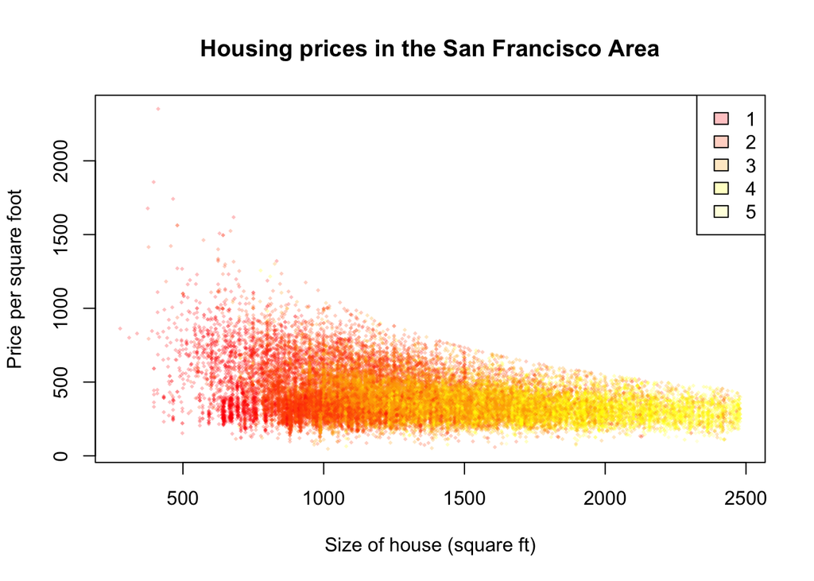

```r
plot(price_per_sqft ~ bsqft, data = SelectArea,
     main = "Housing prices in the San Francisco Area",
     xlab = "Size of house (square ft)",
     ylab = "Price per square foot",
     col = brCols, pch = 18, cex = 0.5)
legend(legend = 1:5, fill = rCols, "topright")
```

# what’s your interpretation of the plot?

# e.g., the trend? the cluster? the comparison? (1 pt.)

```r
#My interpretation of the plot is that the more bedrooms a house has, the bigger it typically is in terms of square feet.
#It also suggests that the less bedrooms it has, the more expensive the house is in terms of price per square foot.
```